# Spectral modelling and predictions using the `caret` package

Pierre Roudier

2025-10-20

The `spectacles` package focuses on making the handling of spectral data (along with its associated attribute data) easy: *by design*, the tasks of tuning and fitting prediction models (either for regression or classification) are out-of-scope. Rather than re-implementing those routines, `spectacles` delegates these tasks to the numerous R packages that facilitates this. In particular, the package works very well with [the `caret` package](https://topepo.github.io/caret/).

```r
library(dplyr)
library(spectacles)
library(caret)
```

Here we demonstrate a simple example of tuning and fitting a prediction model for the soil organic carbon content field of the `australia` dataset that is shipped with the `spectacles` package. This vignette assumes some basic understanding of the `caret` package. The reader is in particular referred to [the short introduction to `caret` vignette](https://cran.r-project.org/package=caret/vignettes/caret.html).

# Loading the example dataset

The `australia` dataset, shipped with the `spectacles` package is a collection of 100 visible near-infrared spectra collected on air-dried soils. More information about this dataset is available on its manual page (`?australia`). The dataset can be loaded quickly using the `load_oz` function:

```r
# This loads the "australia" example dataset
oz <- load_oz()
```

```
#> Wavelength range: 350 to 2500 nm
#> Spectral resolution: 1 nm
```

This creates the object `oz`, of class `SpectraDataFrame`. A dedicated vignette will be available to explain the creation of `SpectraDataFrame` objects from scratch.

# Pre-processing

Pre-processing will be the focus of a dedicated vignette. Here we keep things simple, and limit pre-processingto remove the splice steps that affect the spectra. This is done using the `splice` function:

```r
oz <- splice(oz)
```

# Data split

First, the `australia` dataset is split into a calibration and a validation set. Here we keep things simple, and use a 75%–25% random split:

```r
set.seed(1) # To make the split reproducible
idx <- sample(1:nrow(oz), size = 75)
oz_calib <- oz[idx, ]
oz_valid <- oz[-idx, ]
```

Note that `SpectraDataFrame` objects can be subsetted simply by using the `[` operator.

# Parametrisation of a PLS model

The main `spectacles` function used to interface with `caret` is the `spectra` function, which extracts the spectral matrix that is associated with analytical data. This matrix represents the predictors used to predict a given outcome (“`x`”), while the outcome of the model (“`y`”) is an analytical attribute, and can be extracted from the `SpectraDataFrame` object using the `$` operator:

```r
# The `spectra` function extracts the spectral matrix...
spec_mat <- spectra(oz)
big.head(spec_mat)
```

```
#>           X350       X351       X352       X353       X354 ...     X2496
#> 28  0.08173233 0.08074037 0.08312159 0.08690414 0.08761925 ... 0.3888433
#> 36  0.10344727 0.09767456 0.09267905 0.09155867 0.10600654 ... 0.3035470
#> 136 0.11363971 0.13762568 0.14234437 0.13608806 0.13451828 ... 0.3524803
#> 194 0.16374375 0.16650400 0.16646151 0.16540240 0.16768558 ... 0.7547905
#> 215 0.09693917 0.10563760 0.10342025 0.09727478 0.10408881 ... 0.4397273
#>         X2497     X2498     X2499     X2500
#> 28  0.3942973 0.3934600 0.3889097 0.3864646
#> 36  0.3016855 0.3077460 0.3116423 0.3036998
#> 136 0.3526042 0.3598545 0.3576893 0.3460697
#> 194 0.7552416 0.7525422 0.7513548 0.7567009
#> 215 0.4433315 0.4389216 0.4340123 0.4373087
```

```r
# ... while analytical data can be accessed using `$`
oz$carbon
```

```
#>   [1] 0.63 0.69 1.44 0.33 1.12 1.14 0.72 1.88 0.30 1.60 0.97 1.16 1.84 1.52 1.44
#>  [16] 1.54 1.04 1.57 1.18 1.10 1.09 1.00 0.58 0.59 0.52 0.55 0.59 0.82 3.12 0.65
#>  [31] 0.73 0.67 1.08 0.79 0.55 0.38 1.31 0.87 1.81 0.87 1.11 3.13 0.49 1.10 1.17
#>  [46] 0.75 1.42 0.72 0.20 3.11 0.11 0.62 0.56 1.21 2.24 0.09 0.05 0.58 1.25 0.80
#>  [61] 1.25 1.09 1.29 1.51 0.98 3.15 1.46 2.10 4.39 2.60 6.44 3.06 3.80 3.94 3.25
#>  [76] 2.34 2.27 5.96 7.91 9.19 4.28 3.63 5.09 8.77 2.89 4.94 5.05 4.66 8.71 4.60
#>  [91] 2.13 3.44 3.73 3.00 3.43 9.53 7.27 7.38 3.02 4.45
```

Therefore, the `train` function can simply be used by populating its `x` and `y` arguments:

```r
fit1 <- train(
  # The `spectra` function extract the spectra matrix
  x = spectra(oz_calib),
  # analytical data can be extracted using `$`
  y = oz_calib$carbon,
  # Here we choose the PLS regression method
  method = "pls",
  # The train function will try 3 possible parameters for the PLS
  tuneLength = 3
)
```

# Using spectroscopy-specific performance metrics

## As part of the model tuning

The `spectacles` even provide a summary functions akin to those in `caret`, but that work better for spectroscopy. The `spectroSummary` function works like the `defaultSummary` function in `caret`, but adds indicators that are popular in spectroscopy, such as RPD, RPIQ, or CCC:

```r
fit2 <- train(
    x = spectra(oz_calib),
    y = oz_calib$carbon,
    method = "pls",
    tuneLength = 10,
    trControl = trainControl(
      # Here we can specify the summary function used during parametrisation
      summaryFunction = spectroSummary
    ),
    # Here we can specifiy which metric to use to optimise the model parameters
    metric = "RPIQ"
)
```

The parametrisation of the resulting model can be plotted and inspected using the usual `caret` tools:

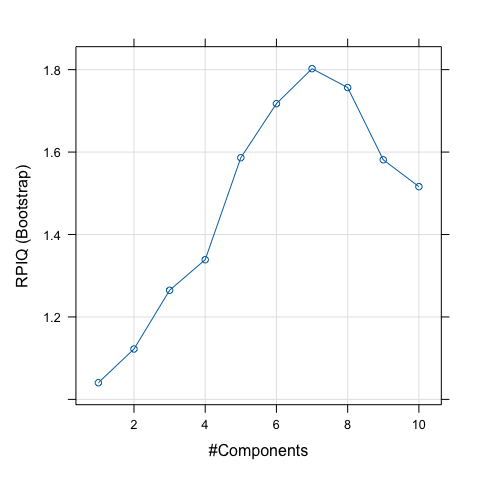

```r
plot(fit2)
```

```r
print(fit2)
```

```
#> Partial Least Squares
#>
#>   75 samples
#> 2151 predictors
#>
#> No pre-processing
#> Resampling: Bootstrapped (25 reps)
#> Summary of sample sizes: 75, 75, 75, 75, 75, 75, ...
#> Resampling results across tuning parameters:
#>
#>   ncomp  RMSE      Rsquared    RPD       RPIQ      CCC         Bias
#>    1     2.270830  0.04109954  1.009247  1.040409  0.06355689   0.028842359
#>    2     2.112723  0.18565942  1.086623  1.122197  0.29007126   0.045418074
#>    3     1.925908  0.34933470  1.222142  1.264717  0.48486626  -0.001460203
#>    4     1.791195  0.45828944  1.301441  1.338876  0.60917078  -0.016411213
#>    5     1.506213  0.62339030  1.539812  1.586311  0.75342460   0.034489914
#>    6     1.397651  0.68215657  1.673905  1.717462  0.79435174   0.078286879
#>    7     1.309171  0.71306886  1.760404  1.802363  0.82416014  -0.006024811
#>    8     1.359387  0.69369083  1.714036  1.756475  0.81396694   0.035286883
#>    9     1.504208  0.65452690  1.553504  1.581330  0.78533423   0.042897974
#>   10     1.572661  0.63015038  1.492047  1.516139  0.76944793   0.020828935
#>   SE
#>   2.313951
#>   2.152752
#>   1.962224
#>   1.825044
#>   1.534687
#>   1.424066
#>   1.333973
#>   1.385142
#>   1.532704
#>   1.602432
#>
#> RPIQ was used to select the optimal model using the largest value.
#> The final value used for the model was ncomp = 7.
```

Different models can also be compared:

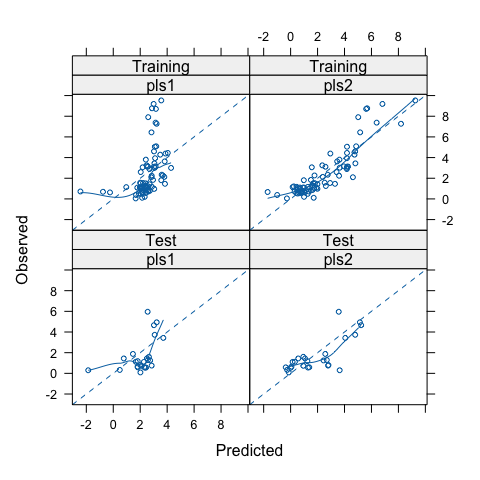

```r
preds <- extractPrediction(
  # Here we specify the `caret` models we want to compare
  models = list(
    pls1 = fit1,
    pls2 = fit2
  ),
  testX = spectra(oz_valid),
  testY = oz_valid$carbon
)

# necessary so 2 PLS model can be compared in `plotObsVsPred`
preds$model <- preds$object

plotObsVsPred(preds)
```

The model `fit2` outperforms the model `fit1`: hardly a surprise as we limited the latter to 3 latent variables, which is clearly too few in this instance.

## During the assessment of the performance of the model

Finally, those specific performance indicators can also be used to asses the final results. PLS predictions can be generated using the `predict` function from the `caret` package, and its result passed to `postResampleSpectro`:

```r
# Simple example for the entire dataset
postResampleSpectro(
  pred = predict(fit2, spectra(oz)),
  obs = oz_valid$carbon
)
```

```
#>      RMSE  Rsquared       RPD      RPIQ       CCC      Bias        SE
#> 2.4148046        NA 0.6614048 0.4182533 0.1667738 0.7262200 4.9291993
```

Again, this function mimics its `caret` equivalent, `postResample`.

A more useful thing to do, from a modelling standpoint, is to compare those performance results on the calibration, validation, and bootstrapped sets (especially the two latter ones):

```r
# Run model predictions and extract performance statistics for
# caliration and validation
res_calibration <- postResampleSpectro(pred = predict(fit2, spectra(oz_calib)), obs = oz_calib$carbon)
res_validation <- postResampleSpectro(pred = predict(fit2, spectra(oz_valid)), obs = oz_valid$carbon)

# Bootstrapped results can be extracted from the `train` object:
res_boot <- fit2$results %>%
  filter(ncomp == fit2$bestTune$ncomp) %>%
  select(names(res_calibration))

# Assemble the calibration, validation, and
# bootstrapped results in a single data.frame
res <- rbind(
  data.frame(type = "Calibration", t(res_calibration)),
  data.frame(type = "Validation", t(res_validation)),
  data.frame(type = "Bootstrap", res_boot)
)
```

Which gives the following results:

| type | RMSE | Rsquared | RPD | RPIQ | CCC | Bias | SE |
| --- | --- | --- | --- | --- | --- | --- | --- |
| Calibration | 1.09 | 0.78 | 2.15 | 2.09 | 0.88 | 0.00 | 1.10 |
| Validation | 1.21 | 0.55 | 1.32 | 0.83 | 0.73 | 0.24 | 1.24 |
| Bootstrap | 1.31 | 0.71 | 1.76 | 1.80 | 0.82 | -0.01 | 1.33 |